# Questionnaire Data Analysis

Merel Vogel

2023-12-13

# Data analysis of survey answers

This file is the data analysis part of a master thesis on uncertainty visualizations in climate projections on maps. The aim is that this file takes the reader through the analysis steps that were taken, and shows some results of the questionnaire that was done.

## Quantification questions

In this section, the quantification questions are analysed. In order to do so, we read in the data, select the questions from the csv data which contains the survey answers, and plot the results in density plots.

### Data prep

Below, we read in the data and show a summary of the survey answers that have numeric values. These questions were the quantification questions on providing minimum and maximum estimates for each of the four maps. In addition, to ease data manipulation and visualization, we exchange the column names from the literal survey questions to “map1_min”, “map1_max”, etc., and split the answers for the minimum estimates and maximum estimates into two separate dataframes. Change the working directory here if you are running the file yourself.

```r
library(dplyr)
library(tidyr)

setwd("/home/merel/Documents/I-CISK/MSc_Thesis_UncertaintyViz/R/responses-analysis/")
answers_path <- ("./data/MSc_Thesis_Questionnaire2.csv")
df <- read.csv(answers_path)

num_df <- df |>
  select(where(is.numeric))

colnames(num_df) <- c("map1_min", "map1_max", "map2_min", "map2_max", "map3_min", "map3_max", "map4_min", "map4_max")
num_df <- pivot_longer(num_df, cols = everything())
custom_order <- c("map1_min", "map2_min", "map3_min", "map4_min", "map1_max", "map2_max", "map3_max", "map4_max")
num_df$name <- factor(num_df$name, levels = custom_order)

# Separate min and max into two dataframes
min_df <- num_df |> filter(grepl("_min$", name))
max_df <- num_df |> filter(grepl("_max$", name))
```

### Mean values

To get a first impression, we calculate the mean per map for the minimum and maximum questions.

```r
map1_min <- num_df |> filter(grepl("map1_min", name)) |> summarise(mean_temp = mean(value)) |> as.numeric() |> round(digits = 2)
map2_min <- num_df |> filter(grepl("map2_min", name)) |> summarise(mean_temp = mean(value)) |> as.numeric() |> round(digits = 2)
map3_min <- num_df |> filter(grepl("map3_min", name)) |> summarise(mean_temp = mean(value)) |> as.numeric() |> round(digits = 2)
map4_min <- num_df |> filter(grepl("map4_min", name)) |> summarise(mean_temp = mean(value)) |> as.numeric() |> round(digits = 2)
map1_max <- num_df |> filter(grepl("map1_max", name)) |> summarise(mean_temp = mean(value)) |> as.numeric() |> round(digits = 2)
map2_max <- num_df |> filter(grepl("map2_max", name)) |> summarise(mean_temp = mean(value)) |> as.numeric() |> round(digits = 2)
map3_max <- num_df |> filter(grepl("map3_max", name)) |> summarise(mean_temp = mean(value)) |> as.numeric() |> round(digits = 2)
map4_max <- num_df |> filter(grepl("map4_max", name)) |> summarise(mean_temp = mean(value)) |> as.numeric() |> round(digits = 2)

cat("Mean estimated value for minimum:\n",
    "Map 1: ", map1_min, "°C \n",
    "Map 2: ", map2_min, "°C \n",
    "Map 3: ", map3_min, "°C \n",
    "Map 4: ", map4_min, "°C \n")
```

```
## Mean estimated value for minimum:
##  Map 1:  22.24 °C
##  Map 2:  23.45 °C
##  Map 3:  22.24 °C
##  Map 4:  22.44 °C
```

```r
cat("Mean estimated value for maximum:\n",
    "Map 1: ", map1_max, "°C \n",
    "Map 2: ", map2_max, "°C \n",
    "Map 3: ", map3_max, "°C \n",
    "Map 4: ", map4_max, "°C \n")
```

```
## Mean estimated value for maximum:
##  Map 1:  26.27 °C
##  Map 2:  26.22 °C
##  Map 3:  26.18 °C
##  Map 4:  24.31 °C
```

### Density Plots

We can now use the new dataframe to create some visualizations using `ggplot2` and `ggridges`.

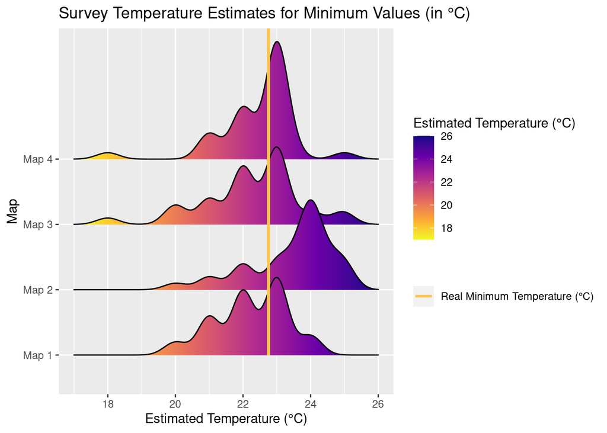

```r
library(ggplot2)
library(ggridges)

y_labels <- c("Map 1", "Map 2", "Map 3", "Map 4")

ggplot(min_df, aes(x=value, y=name, fill = after_stat(x))) +
  geom_density_ridges_gradient() +
  scale_fill_viridis_c(name = "Estimated Temperature (°C)", option = "C", direction = -1) +
  scale_y_discrete(labels = y_labels) +
  geom_segment(aes(x = 22.75, y = 1, xend = 22.75, yend = 6, color="#fec44f"), linewidth = 1) +
  scale_color_identity(name = "", guide = "legend",
                    breaks = c("#fec44f"), labels = c("Real Minimum Temperature (°C)")) +
  labs(
    x = "Estimated Temperature (°C)",
    y = "Map",
    title = "Survey Temperature Estimates for Minimum Values (in °C)")
```

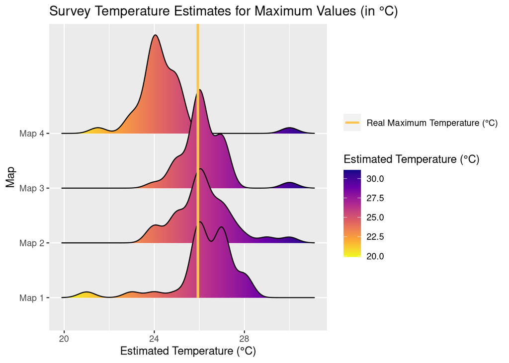

```r
ggplot(max_df, aes(x=value, y=name, fill = after_stat(x))) +
  geom_density_ridges_gradient() +
  scale_fill_viridis_c(name = "Estimated Temperature (°C)", option = "C", direction = -1) +
  scale_y_discrete(labels = y_labels) +
  geom_segment(aes(x = 25.93, y = 1, xend = 25.93, yend = 6, color = "#fec44f"), linewidth = 1) +
  scale_color_identity(name = "", guide = "legend",
                    breaks = c("#fec44f"), labels = c("Real Maximum Temperature (°C)")) +
  labs(
    x = "Estimated Temperature (°C)",
    y = "Map",
    title = "Survey Temperature Estimates for Maximum Values (in °C)")
```

## Uncertainty questions

This section tries to analyse the results of the questions on uncertainty. To do this, as a first step we take the original dataframe and subset the columns that contain the answer to the question “How certain is it that the mean temperature at the left encircled area will reach a temperature above 25 °C?” and the question “Is it more likely that the temperature at the left encircled area or the right encircled area will be below 23 °C?”. Some data preparation has to be done in this section as well, as there were some typos in the dataset. Finally, the results are shown in barcharts.

```r
col_name_unc_above <- colnames(df)[7]
col_name_unc_below <- colnames(df)[8]
unc_above_df <- df |> select(contains(col_name_unc_above))
colnames(unc_above_df) <- c("Map 1", "Map 2", "Map 3", "Map 4")
unc_above_df <- pivot_longer(unc_above_df, cols = everything())
unc_below_df <- df |> select(contains(col_name_unc_below))
colnames(unc_below_df) <- c("Map 1", "Map 2", "Map 3", "Map 4")
unc_below_df <- pivot_longer(unc_below_df, cols = everything())
```

### Data cleaning: typo correction

During the survey rollout, one of the users saw that there was a small mistake in one of the possible answers. The answer said “The right encircled area is more likely to reach a temperature below 23 °C than the right encircled area”, while, of course, that should have been “The right encircled area is more likely to reach a temperature below 23 °C than the left encircled area”. This was corrected after the survey was filled out 5 times, but should not affect the results. The typo is corrected below in those first five answers. There was also one period-symbol (“.”) too much which was corrected after one response.

```r
# Replace faulty answer options with correct ones
faulty_value <- unique(unc_below_df$value)[1]
replacement_value <- unique(unc_below_df$value)[5]
unc_below_df <- unc_below_df |>
  mutate(value = if_else(value == faulty_value, replacement_value, value))

faulty_value2 <- "The left encircled area is more likely to reach a temperature below 23 °C than the right encircled area.."
replacement_value2 <- "The left encircled area is more likely to reach a temperature below 23 °C than the right encircled area."
unc_below_df <- unc_below_df |>
  mutate(value = if_else(value == faulty_value2, replacement_value2, value))

faulty_value3 <- "It’s not possible to derive that from this map"
replacement_value3 <- "It’s not possible to derive that from this map."
unc_below_df <- unc_below_df |>
  mutate(value = if_else(value == faulty_value3, replacement_value3, value))

correct_answer_wcheck <- "Somewhat certain ✅ "
correct_answer <- "Somewhat certain"
unc_above_df <- unc_above_df |>
  mutate(value = if_else(value == correct_answer, correct_answer_wcheck, value))
```

### Bar Chart Plots

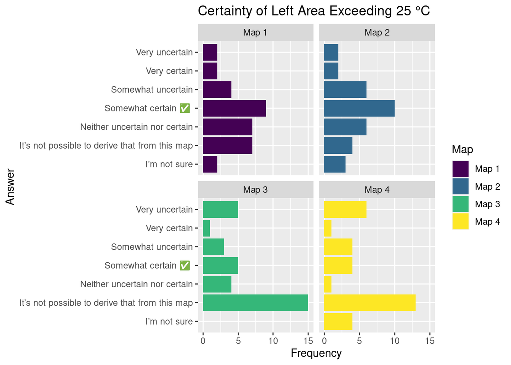

```r
ggplot(unc_above_df, aes(fill = name, y = value)) +
  geom_bar(stat = "count") +
  scale_fill_viridis_d() +
  facet_wrap(~name) +
  labs(
    fill = "Map",
    x = "Frequency",
    y = "Answer",
    title = "Certainty of Left Area Exceeding 25 °C")
```

Below, the answers for the question “Is it more likely that the temperature at the left encircled area or the right encircled area will be below 23 °C?” are visualized in a separate bar chart for each map. Each map is visualized separately, as this provided a more readable graph as most of the answers were centred on one value.

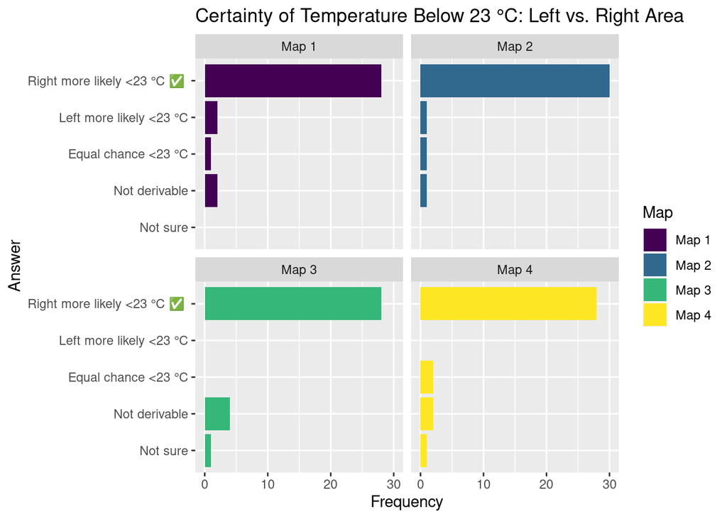

```r
y_answer_labels <- c("Not sure",
                     "Not derivable",
                     "Equal chance <23 °C",
                     "Left more likely <23 °C",
                     "Right more likely <23 °C ✅ ")

ggplot(unc_below_df, aes(fill = name, y = value)) +
  geom_bar(stat = "count") +
  scale_fill_viridis_d() +
  scale_y_discrete(labels = y_answer_labels) +
  facet_wrap(~name) +
  labs(
    fill = "Map",
    x = "Frequency",
    y = "Answer",
    title = "Certainty of Temperature Below 23 °C: Left vs. Right Area")
```

The answers to this question are clearly centered on the option that the right encircled area was more likely to reach a temperature below 23 °C than the right encircled area. This was also the correct answer. No real differences between the maps can be observed.

## Possible map combinations and preferences

Below, the answer for the question on preference of map combinations is displayed. The unique answers are displayed along with their frequency.

```r
table(df$Imagine.you.would.decide.which.uncertainty.maps.are.incorporated.into.a.climate.service.application..Is.there.any.combination.of.maps.1.4.that.you.would.find.helpful..If.so..please.tick.the.boxes.of.the.maps.that.you.would.think.would.be.helpful.together..)
```

[output not shown]

[output cut: 11 more lines]